# Proyecto - Contingencias de Vida I

Estudiantes

Luis Fernando Amey Apuy - C20470 Fabián Brenes Thomas - C21380 Marco Antonio Guardia Ortiz - C23521 Anthony Mauricio Jiménez Navarro - C24067 Laura Jimena Villacís Delgado - C28386

2024-05-13

# Importar y descargar los datos

```r
library(readxl)
library(readr)
library(tidyverse)
```

```r
library(ggplot2)
ABC <- read_excel("data/Base de datos.xlsx")
SUPEN <- read_excel("data/tavid2000-2150.xls")
SUPEN_num <- as.data.frame(lapply(SUPEN, as.numeric), stringsAsFactors = FALSE)
```

# Observaciones iniciales

## Transformaciones menores

```r
#Agregar columna de edad:
ABC$Edad = 2023 - as.double(format(ABC$`Fecha de nacimiento`, format="%Y"))
ABC[ABC$Sexo == 'M',]$Sexo <- 'Hombres' #hombres: 1
ABC[ABC$Sexo == 'F',]$Sexo <- 'Mujeres'#Mujeres: 2
```

## Transformaciones y visualizaciones iniciales

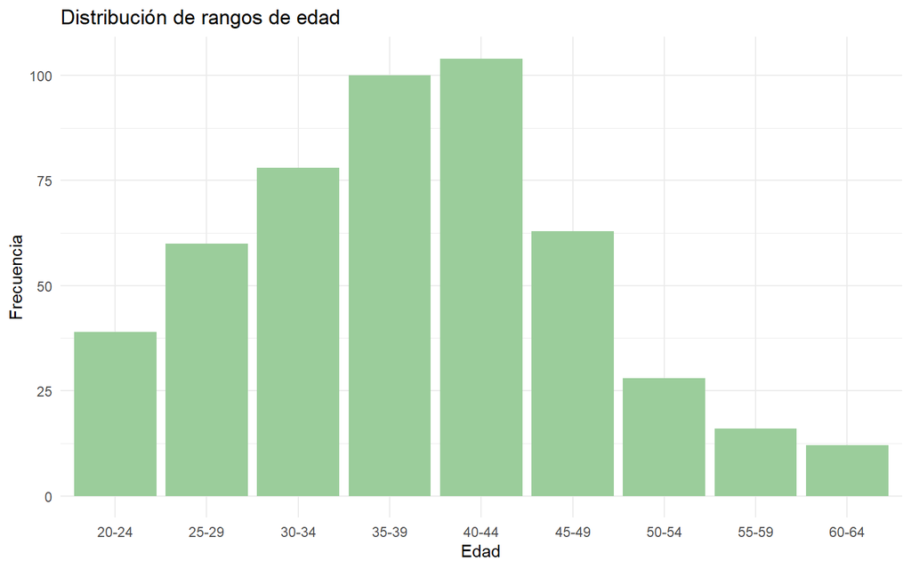

```r
#Agregar una columna de rango de edad.
#Rangos:  20-24, 25-29, 30-34, 35-39, 40-44, 45-49, 50-54, 55-59, 60-64, +65
breaks<-c(20,24,29,34,39,44,49,54,59,65)
labels<-c("20-24", "25-29", "30-34", "35-39", "40-44", "45-49", "50-54", "55-59", "60-64")
ABC$rango_edad<-cut(ABC$Edad, breaks=breaks, labels=labels, right=FALSE)

# Agrupar los datos por rango de edad y sexo, y calcular la frecuencia
tabla_rangos_sexo <- table(ABC$rango_edad, ABC$Sexo)
tabla_porcentaje_sexo <- prop.table(tabla_rangos_sexo, margin=1) * 100

tabla_rangos_sexo <- data.frame(
  rango_edad = rep(rownames(tabla_rangos_sexo), times=ncol(tabla_rangos_sexo)),
  sexo = rep(colnames(tabla_rangos_sexo), each=nrow(tabla_rangos_sexo)),
  frecuencia = as.vector(tabla_rangos_sexo),
  porcentaje = round(as.vector(tabla_porcentaje_sexo), 2)
)

#Observaciones de distribuciones
ggplot(data=tabla_rangos_sexo, aes(x=rango_edad, y=frecuencia))+
geom_bar(stat="identity", fill="darkseagreen3")+
labs(title="Distribución de rangos de edad", x="Edad", y="Frecuencia")+
theme_minimal()
```

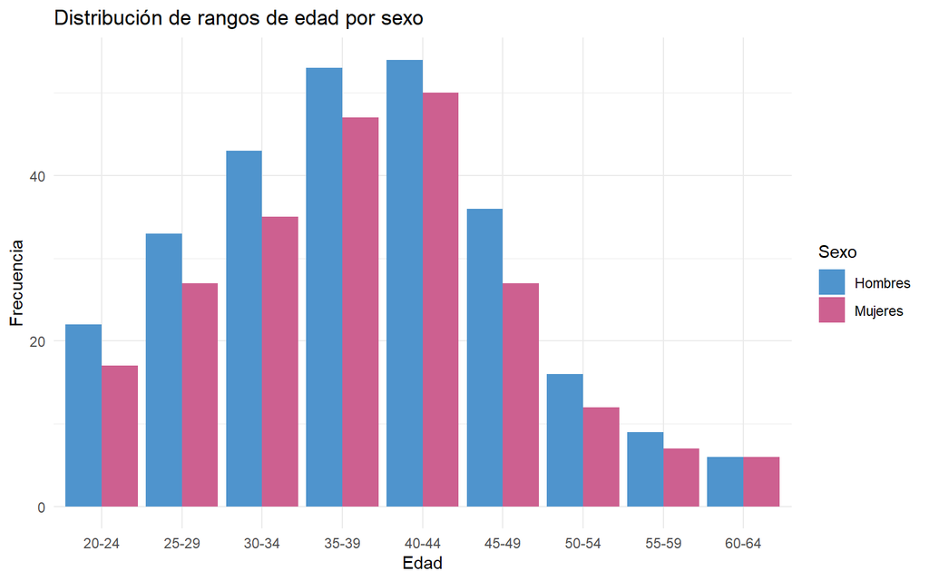

```r
ggplot(data=tabla_rangos_sexo, aes(x=rango_edad, y=frecuencia, fill=sexo)) +
  geom_bar(stat="identity", position="dodge") +
  labs(title="Distribución de rangos de edad por sexo", x="Edad", y="Frecuencia") +
  scale_fill_manual(name="Sexo", values=c("Hombres"="steelblue3", "Mujeres"="hotpink3"), labels=c("Hombres", "Mujeres"))+
  theme_minimal()
```

## Transformaciones menores finales

```r
ABC[ABC$Sexo == 'Hombres',]$Sexo <- "1"
ABC[ABC$Sexo == 'Mujeres',]$Sexo <- "2"
ABC$Sexo <- as.double(ABC$Sexo)
```

# Función para recolectar los qx de un df agrupado

```r
#' Calcula las probabilidades de vida para todos los años de cada persona
#' @param df_obs caracteristicas de cada persona
#' @param df_prob tabla dinámica de las proabilidades de muerte
#' @return all_qx (una lista que adentro contiene: 1. Una lista con las probabilidades de sobrevivencia para cada persona. 2. El sexo. 3. La edad)
get_qx <- function(df_obs, df_prob){
  c <- 1 #Contador para las personas

  #se genera la lista vacía que vamos a devolver
  all_qx = list()

  #se itera sobre todas las observaciones del df_obs
  for (i in 1:length(df_obs[[1]])){ #CAMBIO: MAS ENTENDIBLE PONER NROW

    #se guarda la edad en x
    x <- df_obs$Edad[i]

    #si no es la primera observación
    if(i != 1) {

      #si la observación pasada tiene la misma edad y sexo, copia las probabilidades y pasa a la siguiente observación
      if((df_obs$Edad[i-1] == x) & (df_obs$Sexo[i] == df_obs$Sexo[i-1])){
        all_qx[c] <- all_qx[c-1] #copia la lista
        c <- c+1 #Actualizamos el contador de personas
        next #Pasamos a la siguiente iteración
      }
    }

    #se actualiza el año a 2024
    y <- 2024 # modificación puesto estaba en 2023

    #Se filtra la base con las probabilidades según el sexo de la observación
    df <- df_prob[df_prob$sex == df_obs$Sexo[i],]

    #Inicializamos la sublista de probabilidades.
    local_qx <- list()

    #Se hace un while para copiar todas las probabilidades de vida de la observación  en cuestión a partir de la edad y el año actual
     n <- 1 #Contador del while
    while (any(df$edad == x & df$year == y)) {
      # Filtrar datos por edad y año actual para encontrar probabilidad de muerte de la persona a esa edad
      qx <- df[df$edad == x & df$year == y , ]$qx

      # Se calcula la probabilidad de sobrevivencia
      local_qx[n] <- 1 - qx
      n <- n + 1

      #Se actualiza la edad y el año
      x <- x + 1
      y <- y + 1
    }
    all_qx[[c]] <- list()
    #Se guarda en una lista las probabilidades, el sexo y la edad
    all_qx[[c]][[1]] <- local_qx
    all_qx[[c]][[2]] <- df_obs$Sexo[i]
    all_qx[[c]][[3]] <- df_obs$Edad[i]

    c <- c+1 #Actualizamos contador de personas
  }

  #Se devuelve la lista con una lista para cada observación
  return(all_qx)
}
```

## Recolectar la probabilidad de muerte/sobrevivencia de cada observación

```r
t <- proc.time() #Tiempo de ejecución
qx <- get_qx(ABC, SUPEN_num) #Probabilidades de muerte para personas de ABC
proc.time() - t
```

```
##    user  system elapsed
##    4.56    0.90    5.65
```

# Proyecciones demográficas

## Función madre: observar las posibilidades de vivir

```r
#Inicializar dataframe, con proyección de vida residual.
proy_per_viva <- data.frame(Año = c(2024:2124), poblacionM = numeric(101),
                            poblacionH = numeric(101))
proy_per_viva$poblacionH[1] = 272
proy_per_viva$poblacionM[1] = 228

#' Calcula la proyección demográfica de toda la población evaluada
#' @param qx Lista de listas con las probabilidades de sobrevivencia de cada individuo para cada año
#' @param df df para 3 columnas: edad, poblacionM, poblacionH, con población inicial M de 272 y población inicial H de 228
#' @return df: con la cantidad de personas vivas que se esperan para el año 2024 más i
proy_viva <- function(qx, df){
  acumH <- numeric(272) + 1 #inicializa vector de tamaño 272 con 1s
  acumM <- numeric(228) + 1 #inicializa vector de tamaño 228 con 1s

  #Iterar sobre los años
  for (i in 1:100){
    m <- 0
    h <- 0

    #Iterar sobre las personas
    for (c in 1:500){

      #Si es hombre
      if(qx[[c]][[2]] == 1){
        h <- h + 1 #sumamos un hombre

        #Si la persona ya no tiene probabilidades de sobrevivencia, entonces pasamos a la siguiente persona
        if(i > length(qx[[c]][[1]])){
          next
        }

      #guarda el ipx para el hombre h
        acumH[h] <- acumH[h]*qx[[c]][[1]][[i]]
      }

      else { #Es mujer
        m <- m +1 #Añadimos una mujer
        if(i > length(qx[[c]][[1]])){
          next
        }
        #guarda el ipx para la mujer m
        acumM[m] <- acumM[m]*qx[[c]][[1]][[i]]
      }
    }
    #Se lo que se espera que cada persona viva individualmente, para obtener      la cantidad esperada de personas que vivan hasta el año i
    df$poblacionH[i+1] <- sum(acumH)
    df$poblacionM[i+1] <- sum(acumM)

  }
  return(df)
}

#Se utiliza la función que calcula la proyección de personas para cada año
proy_per_viva <- proy_viva(qx, proy_per_viva)
#Se redondean las proyecciones a 8 decimales
proy_per_viva$poblacionM <- round(proy_per_viva$poblacionM, 8)
proy_per_viva$poblacionH <- round(proy_per_viva$poblacionH, 8)
```

## Caso contrario

```r
#Se calcula la cantidad de personas muertas de la siguiente manera, ya que es el complemento de las personas vivas
proy_per_muerta <- proy_per_viva
proy_per_muerta$poblacionM <- 228 - proy_per_muerta$poblacionM
proy_per_muerta$poblacionH <- 272 - proy_per_muerta$poblacionH
```

## Seccionar a solo empleados vivos

```r
proy_emp_viva <- data.frame(Año = c(2024:2124), poblacionM = numeric(101), poblacionH = numeric(101))
proy_emp_viva$poblacionH[1] = 272
proy_emp_viva$poblacionM[1] = 228

#'
#' @param qx Lista de listas con las probabilidades de sobrevivencia de cada individuo para cada año
#' @param df df para 3 columnas: edad, poblacionM, poblacionH, con población inicial M de 272 y población inicial H de 228
#' @return df: Proyección demográfica de empleados activos
proy_emp_vivos <- function(qx, df){

  acumH <- numeric(272) + 1 #inicializa vector de tamaño 272 con 1s
  acumM <- numeric(228) + 1 #incializa vector de tamaño 228 con 1s

  #iteramos sobre los años
  for (i in 1:100){
    m <- 0 #contador de mujeres
    h <- 0 #contador de hombres

    #Iterar sobre las personas
    for (c in 1:500){

     #Si es hombre
      if(qx[[c]][[2]] == 1){
        h <- h + 1

         #Si la persona ya no tiene probabilidades de sobrevivencia, entonces pasamos a la siguiente persona
        if(i > length(qx[[c]][[1]])){
          next
        }

        #Si la persona tiene más de 65 (edad +año) pasamos a la siguiente
        if(65 < qx[[c]][[3]] + i){
          acumH[h] <- 0
          next
        }

        #guarda el ipx para el hombre h
        acumH[h] <- acumH[h]*qx[[c]][[1]][[i]]
      }

      #Si es mujer
      else {
        m <- m +1

        #Si la persona ya no tiene probabilidades de sobrevivencia, entonces pasamos a la siguiente persona
        if(i > length(qx[[c]][[1]])){
          next

        }

        #Si la persona tiene más de 65 (edad +año) pasamos a la siguiente
        if(65 < qx[[c]][[3]] + i){
          acumM[m] <- 0
          next
        }

         #guarda el ipx para la mujer m
        acumM[m] <- acumM[m]*qx[[c]][[1]][[i]]
      }
    }
     # Se obtiene la cantidad esperada de personas que vivan hasta el año i         sumando lo que se espera que cada persona viva individualmente
    df$poblacionH[i+1] <- sum(acumH)
    df$poblacionM[i+1] <- sum(acumM)
  }
  return(df)
}

#Se utiliza la función que calcula la proyección de personas para cada año
proy_emp_viva <- proy_emp_vivos(qx, proy_emp_viva)
#Se redondean las proyecciones a 8 decimales
proy_emp_viva$poblacionM <- round(proy_emp_viva$poblacionM, 8)
proy_emp_viva$poblacionH <- round(proy_emp_viva$poblacionH, 8)
```

## Seccionar a solo pensionados vivos

```r
#Se crea el data frame para las proyecciones de las personas pensionadas
proy_pen_viva <- data.frame(Año = c(2024:2124), poblacionM = numeric(101), poblacionH = numeric(101))

#'Calcula para proyección demográfica de los pensionados
#' @param qx Lista de listas con las probabilidades de sobrevivencia de cada individuo para cada año
#' @param df df para 3 columnas: edad, poblacionM, poblacionH, con población inicial M de 272 y población inicial H de 228
#' @return df: Proyección demográfica de empleados pensionados
proy_pen_vivos <- function(qx, df){
  acumH <- numeric(272) + 1
  acumM <- numeric(228) + 1

  #Se itera sobre los años
  for (i in 1:100){

    m <- 0
    h <- 0

    #Se genera un vector para llevar cuenta de las personas pensionadas
    penH <- numeric(272)
    penM <- numeric(228)

    #Se itera sobre todas las personas
    for (c in 1:500){

      #Si es hombre
      if(qx[[c]][[2]] == 1){
        h <- h + 1

        #Si la persona ya no tiene probabilidades de vivir
        if(i > length(qx[[c]][[1]])){
          next
        }

        #Si la persona tiene más de 65 años entonces se pone un uno en el            vector para llevar la cuenta de los pensionados
        if(65 < qx[[c]][[3]] + i){
          penH[h] <- 1
        }

        #Se van guardando las probabilidades de vida en penH solo para los            pensionados
        acumH[h] <- acumH[h]*qx[[c]][[1]][[i]]
        penH[h] <- penH[h] * acumH[h]
      }
      #Si es mujer
      else {
        m <- m +1

        #Si la persona ya no tiene probabilidades de vivir
        if(i > length(qx[[c]][[1]])){
          next
        }

        #Si la persona tiene más de 65 años entonces se pone un uno en el            vector para llevar la cuenta de los pensionados
        if(65 < qx[[c]][[3]] + i){
          penM[m] <- 1
        }

        #Se van guardando las probabilidades de vida en penM solo para los          pensionados
        acumM[m] <- acumM[m]*qx[[c]][[1]][[i]]
        penM[m] <- penM[m]*acumM[m]
      }
    }

    # Se obtiene la cantidad esperada de personas que vivan hasta el año i      sumando lo que se espera que cada persona viva individualmente
    df$poblacionH[i+1] <- sum(penH)
    df$poblacionM[i+1] <- sum(penM)
  }
  return(df)
}

#Se utiliza la función que calcula la proyección de personas para cada año
proy_pen_viva <- proy_pen_vivos(qx, proy_pen_viva)
#Se redondean las probabilidades a 8 decimales
proy_pen_viva$poblacionM <- round(proy_pen_viva$poblacionM, 8)
proy_pen_viva$poblacionH <- round(proy_pen_viva$poblacionH, 8)
```

## Seccionar a solo empleados muertos

```r
#Crea un data frame para guardar la proyección demográfica de las muertes de los empleados
proy_emp_muerta <- data.frame(Año = c(2024:2124), poblacionM = numeric(101), poblacionH = numeric(101))

#'Calcula para proyección demográfica de las muertes de empleados activos
#' @param qx Lista de listas con las probabilidades de sobrevivencia de cada individuo para cada año
#' @param df df para 3 columnas: edad, poblacionM, poblacionH, con población inicial M de 272 y población inicial H de 228
#' @return df: Proyección demográfica de las muertes de los empleados activos
proy_emp_dead <- function(qx, df){
  acumH <- numeric(272) + 1
  acumM <- numeric(228) + 1

  #Se itera sobre los años
  for (i in 1:100){
    m <- 0
    h <- 0

    #Se crean vectores con 0s para guardar las probabilidades de muerte  personas activas
    localH <- numeric(272)
    localM <- numeric(228)

    #Se itera sobre cada persona
    for (c in 1:500){
      if(qx[[c]][[2]] == 1){
        h <- h + 1
        if(i > length(qx[[c]][[1]])){
          next
        }
        #Si la persona ya es mayor a 65, se cuenta como pensionada y no se            guardan sus proabilidades de muerte
        if(65 < qx[[c]][[3]] + i){
          acumH[h] <- 0
          next
        }

        #Se guardan las probabilidades de muerte para las personas activas
        localH[h] <- acumH[h]*(1 - qx[[c]][[1]][[i]])

        #Se actualizan las probabilidades de sobrevivencia
        acumH[h] <- acumH[h]*qx[[c]][[1]][[i]]

      } else { #Si es mujer
        m <- m +1
        if(i > length(qx[[c]][[1]])){
          next
        }
        if(65 < qx[[c]][[3]] + i){
          acumM[m] <- 0
          next
        }
        localM[m] <- acumM[m]*(1 - qx[[c]][[1]][[i]])
        acumM[m] <- acumM[m]*qx[[c]][[1]][[i]]

      }
    }
    #Se calcula la esperanza de muertes en el año i y se le suma las muertes del año anterior.
    df$poblacionH[i+1] <- sum(localH) + df$poblacionH[i]
    df$poblacionM[i+1] <- sum(localM) + df$poblacionM[i]
  }
  return(df)
}

#Aplicamos la función
proy_emp_muerta <- proy_emp_dead(qx, proy_emp_muerta)
proy_emp_muerta$poblacionM <- round(proy_emp_muerta$poblacionM, 8)
proy_emp_muerta$poblacionH <- round(proy_emp_muerta$poblacionH, 8)
```

## Seccionar a solo pensionados muertos

```r
#Crea un data frame para guardar la proyección demográfica de las muertes de los pensionados


proy_pen_muerta <- data.frame(Año = c(2024:2124), poblacionM = numeric(101), poblacionH = numeric(101))

#'Calcula para proyección demográfica de las muertes de pensionados
#' @param qx Lista de listas con las probabilidades de sobrevivencia de cada individuo para cada año
#' @param df df para 3 columnas: edad, poblacionM, poblacionH, con población inicial M de 272 y población inicial H de 228
#' @return df: Proyección demográfica de las muertes de los pensionados
proy_pen_dead <- function(qx, df){

  acumH <- numeric(272) + 1
  acumM <- numeric(228) + 1

  #Se itera sobre los años
  for (i in 1:100){
    m <- 0
    h <- 0

    #inicializamos vectores en 0s para guardar probabilidades de muerte para los pensionados
    penH <- numeric(272)
    penM <- numeric(228)

    for (c in 1:500){
      if(qx[[c]][[2]] == 1){
        h <- h + 1

        if(i > length(qx[[c]][[1]])){
          next
        }


        #Si la persona tiene más de 65 años entonces se pone un uno en el            vector para llevar la cuenta de los pensionados
        if(65 < qx[[c]][[3]] + i){
          penH[h] <- 1
        }

        #Se van guardando las probabilidades de muerte en penH solo para los  pensionados
        penH[h] <- penH[h] * acumH[h] *(1 - qx[[c]][[1]][[i]])
        acumH[h] <- acumH[h]*qx[[c]][[1]][[i]]
      } else { #si es mujer
        m <- m +1

        if(i > length(qx[[c]][[1]])){
          next
        }
        if(65 < qx[[c]][[3]] + i){
          penM[m] <- 1
        }
        #Se van guardando las probabilidades de vida en penM solo para los          pensionados
        penM[m] <- penM[m]*acumM[m]*(1-qx[[c]][[1]][[i]])
        acumM[m] <- acumM[m]*qx[[c]][[1]][[i]]
      }
    }

    #Se calcula la esperanza de muertes en el año i y se le suma las muertes     del año anterior.
    df$poblacionH[i+1] <- sum(penH) + df$poblacionH[i]
    df$poblacionM[i+1] <- sum(penM) + df$poblacionM[i]
  }
  return(df)
}
proy_pen_muerta <- proy_pen_dead(qx, proy_pen_muerta)
proy_pen_muerta$poblacionM <- round(proy_pen_muerta$poblacionM, 8)
proy_pen_muerta$poblacionH <- round(proy_pen_muerta$poblacionH, 8)
```

# Resumir los resultados demográficos

## En la proyección de mujeres

```r
#Un df con todas las proyecciones de las mujeres
proy_mujeres <- data.frame(
  año = 2024:2124,
  proy_vivas = proy_per_viva$poblacionM,
  proy_muertas = proy_per_muerta$poblacionM,
  proy_emp_vivas = proy_emp_viva$poblacionM,
  proy_pen_vivas = proy_pen_viva$poblacionM,
  proy_emp_muertas = proy_emp_muerta$poblacionM,
  proy_pen_muertas = proy_pen_muerta$poblacionM
)
```

### Observación de la data

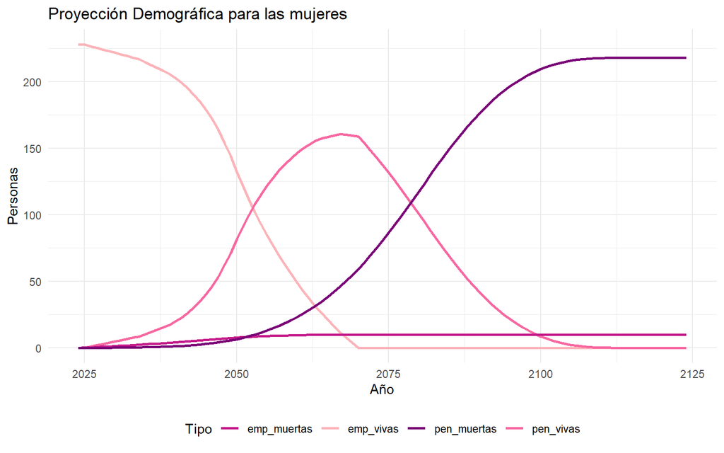

## En la proyección de hombres

```r
#Un df con todas las proyecciones de los hombres
proy_hombres <- data.frame(
  año = 2024:2124,
  proy_vivos = proy_per_viva$poblacionH,
  proy_muertos = proy_per_muerta$poblacionH,
  proy_emp_vivos = proy_emp_viva$poblacionH,
  proy_pen_vivos = proy_pen_viva$poblacionH,
  proy_emp_muertos = proy_emp_muerta$poblacionH,
  proy_pen_muertos = proy_pen_muerta$poblacionH
)
```

### Observación de la data

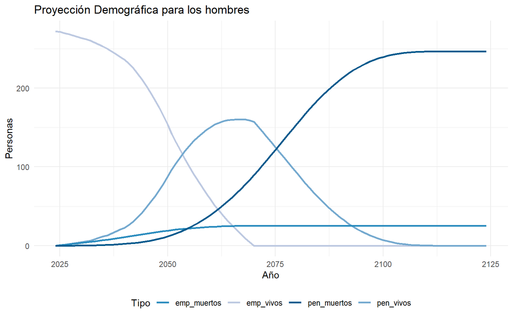

## Observación de la data general

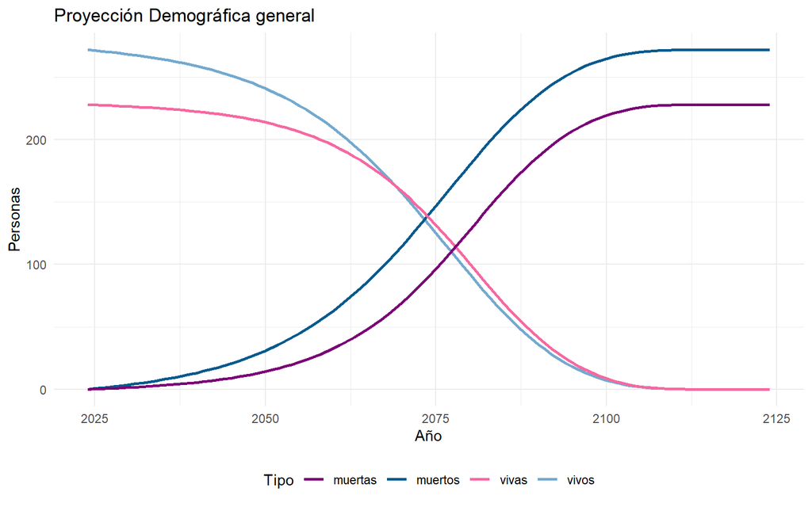

## Gráficos para el resporte actuarial

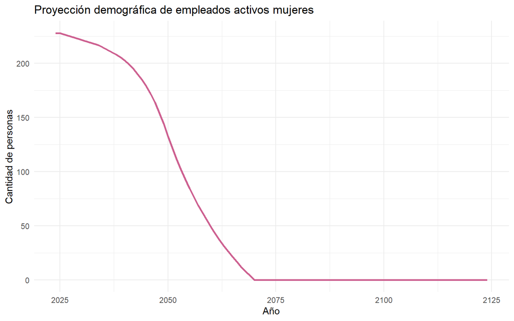

```r
ggplot() +
  geom_line(data = proy_mujeres,
            aes(x = año, y = proy_emp_vivas, color = "vivos"),
            size = 1) +
  labs(
    x = "Año",
    y = "Cantidad de personas",
    title = "Proyección demográfica de empleados activos mujeres"
  ) +
  scale_color_manual(
    values = c('vivos'='hotpink3')) +
  theme_minimal() +
  theme(legend.position = 'none') +
  scale_y_continuous(breaks = seq(0, 228, by = 50))
```

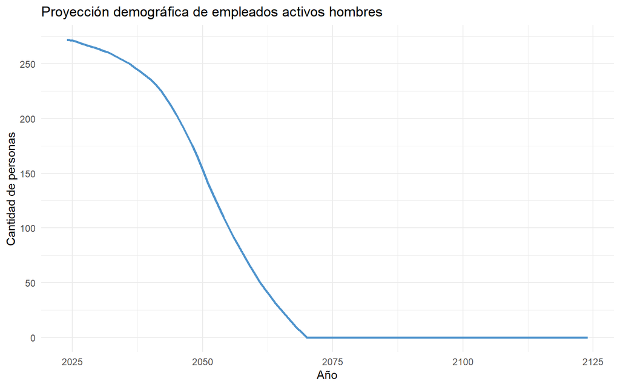

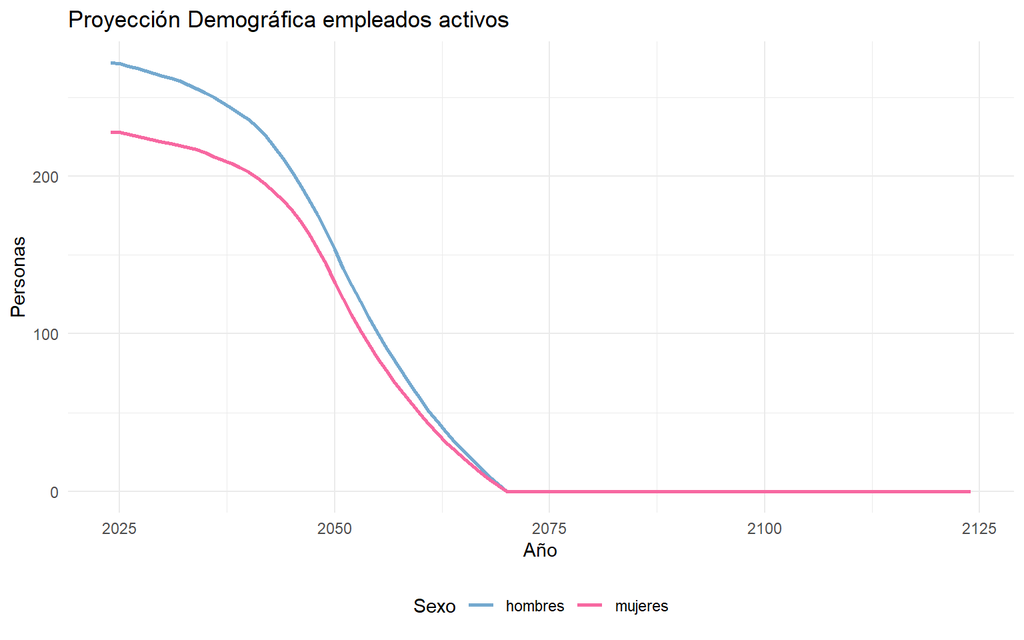

```r
ggplot() +
  geom_line(data = proy_hombres,
            aes(x = año, y = proy_emp_vivos, color = "vivos"),
            size = 1) +
  labs(
    x = "Año",
    y = "Cantidad de personas",
    title = "Proyección demográfica de empleados activos hombres"
  ) +
  scale_color_manual(
    values = c('vivos'='steelblue3')) +
  theme_minimal() +
  theme(legend.position = 'none') +
  scale_y_continuous(breaks = seq(0, 272, by = 50))
```

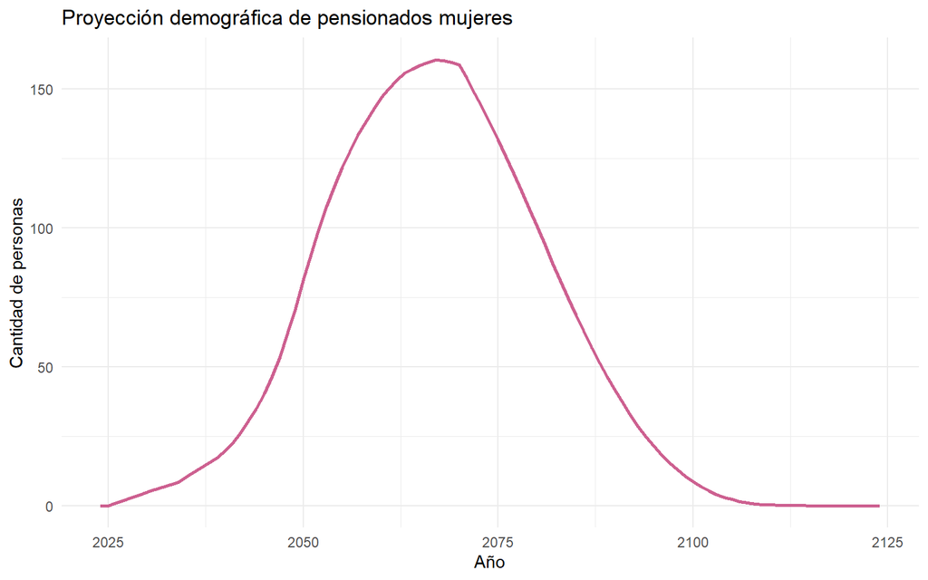

```r
ggplot() +
  geom_line(data = proy_mujeres,
            aes(x = año, y = proy_pen_vivas, color = "vivos"),
            size = 1) +
  labs(
    x = "Año",
    y = "Cantidad de personas",
    title = "Proyección demográfica de pensionados mujeres"
  ) +
  scale_color_manual(
    values = c('vivos'='hotpink3')) +
  theme_minimal() +
  theme(legend.position = 'none') +
  scale_y_continuous(breaks = seq(0, 228, by = 50))
```

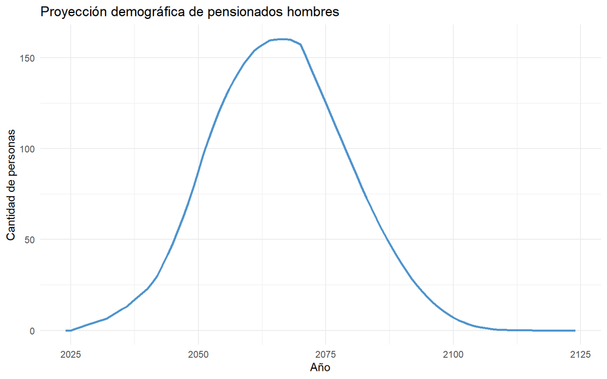

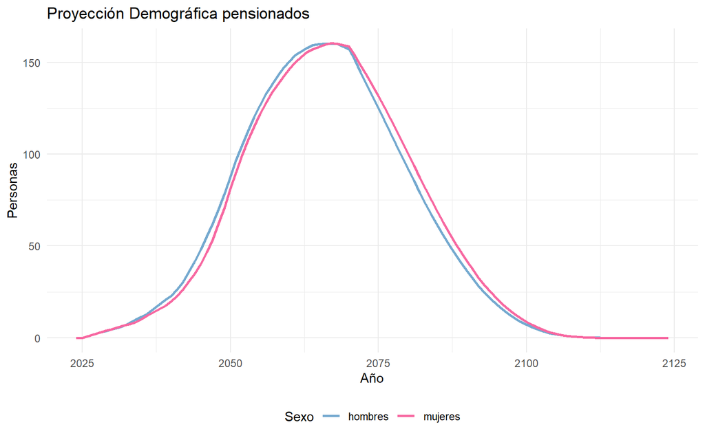

```r
ggplot() +
  geom_line(data = proy_hombres,
            aes(x = año, y = proy_pen_vivos, color = "vivos"),
            size = 1) +
  labs(
    x = "Año",
    y = "Cantidad de personas",
    title = "Proyección demográfica de pensionados hombres"
  ) +
  scale_color_manual(
    values = c('vivos'='steelblue3')) +
  theme_minimal() +
  theme(legend.position = 'none') +
  scale_y_continuous(breaks = seq(0, 272, by = 50))
```

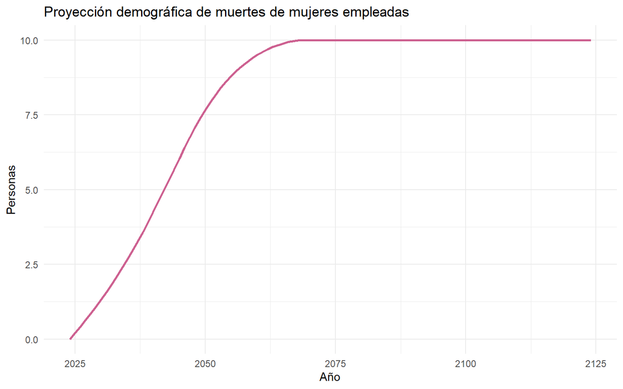

```r
ggplot() +
  geom_line(
    data = proy_mujeres,
    aes(x = año, y = proy_emp_muertas, color = "emp_muertas"),
    size = 1
  ) +
  scale_color_manual(
    values = c(
      "emp_muertas" = "hotpink3"
    )
  ) +
  labs(
    x = "Año",
    y = "Personas",
    title = "Proyección demográfica de muertes de mujeres empleadas",
    color = "Tipo"
  ) +
  theme_minimal() +
  theme(legend.position = 'none')
```

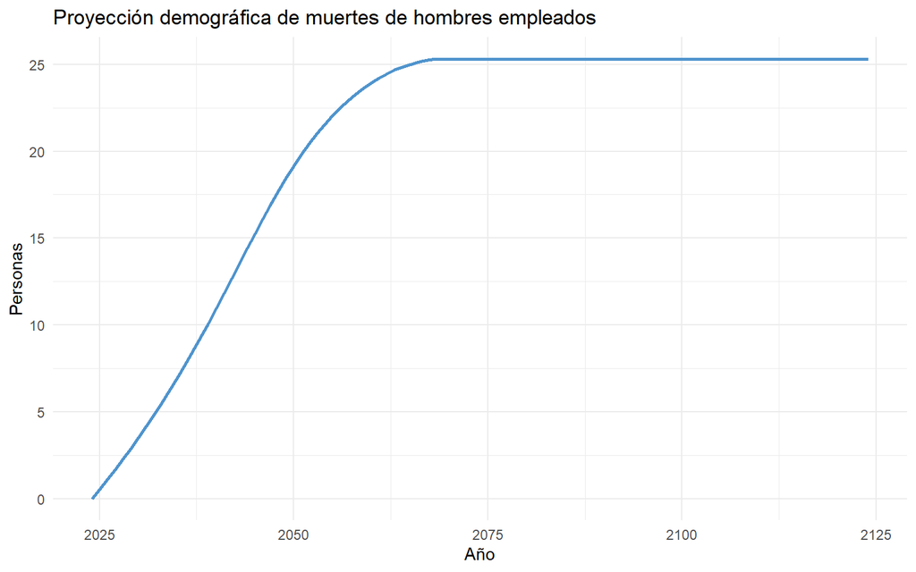

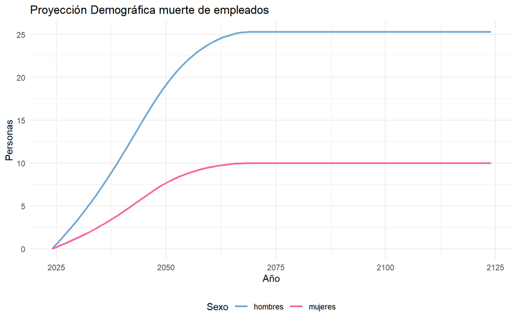

```r
ggplot() +
  geom_line(
    data = proy_hombres,
    aes(x = año, y = proy_emp_muertos, color = "emp_muertos"),
    size = 1
  ) +
  scale_color_manual(
    values = c(
      "emp_muertos" = "steelblue3"
    )
  ) +
  labs(
    x = "Año",
    y = "Personas",
    title = "Proyección demográfica de muertes de hombres empleados",
    color = "Tipo"
  ) +
  theme_minimal() +
  theme(legend.position = 'none')
```

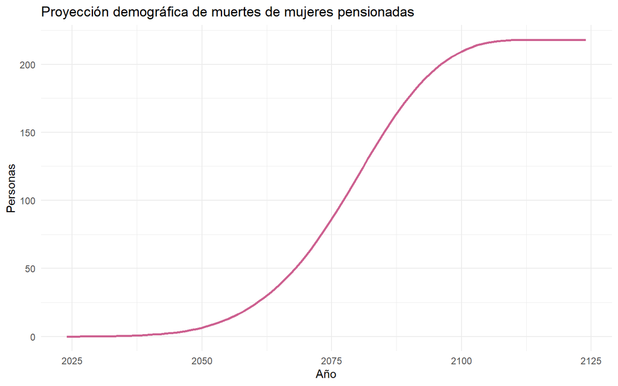

```r
ggplot() +
  geom_line(
    data = proy_mujeres,
    aes(x = año, y = proy_pen_muertas, color = "pen_muertas"),
    size = 1
  ) +
  scale_color_manual(
    values = c(
      "pen_muertas" = "hotpink3"
    )
  ) +
  labs(
    x = "Año",
    y = "Personas",
    title = "Proyección demográfica de muertes de mujeres pensionadas",
    color = "Tipo"
  ) +
  theme_minimal() +
  theme(legend.position = 'none')
```

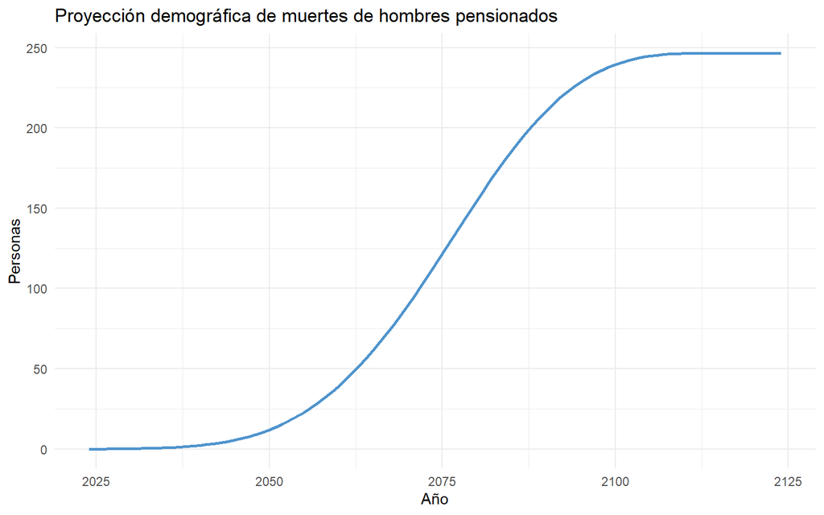

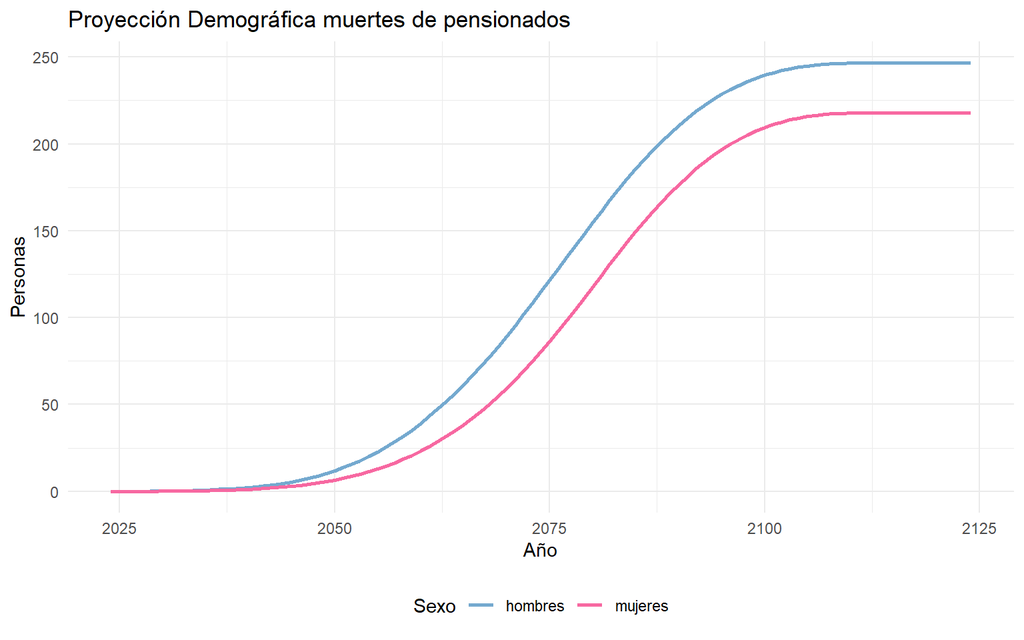

```r
ggplot() +
  geom_line(
    data = proy_hombres,
    aes(x = año, y = proy_pen_muertos, color = "pen_muertos"),
    size = 1
  ) +
  scale_color_manual(
    values = c(
      "pen_muertos" = "steelblue3"
    )
  ) +
  labs(
    x = "Año",
    y = "Personas",
    title = "Proyección demográfica de muertes de hombres pensionados",
    color = "Tipo"
  ) +
  theme_minimal() +
  theme(legend.position = 'none')
```

## Verificar los resultados

```r
# suma_hombres <- proy_hombres$proy_emp_vivos +
#   proy_hombres$proy_pen_vivos +
#   proy_hombres$proy_emp_muertos +
#   proy_hombres$proy_pen_muertos
#
# suma_mujeres <- proy_mujeres$proy_emp_vivas +
#   proy_mujeres$proy_pen_vivas +
#   proy_mujeres$proy_emp_muertas +
#   proy_mujeres$proy_pen_muertas
```

```r
rm(proy_emp_muerta)
rm(proy_per_viva)
rm(proy_per_muerta)
rm(proy_emp_viva)
rm(proy_pen_viva)
rm(proy_pen_muerta)
rm(t)
rm(proy_emp_dead)
rm(proy_viva)
rm(proy_pen_vivos)
rm(proy_pen_dead)
rm(proy_emp_vivos)
```

# Proyección financiera

## Proyección del VP de los pagos de beneficio de muerte de empleados activos

```r
#' Calcula el valor presente de las obligaciones de cada año por muerte de los empleados activos.
#' @param df Recibe el df de proy_hombres o proy_mujeres
#' @return Devuelve un vector con el valor presente para cada año
proy_emp_vp <- function(df){
  #La columna 6 es la de la proyección demógrafica de las muertes de los      empleados activos
  col <- df[[6]]

  #Fórmula=cantidad de muerte*suma asegurada*v^cantidad de años desde 2024
  for (i in 1:100){
    col[102-i] <- (col[102-i]-
                     col[101-i])*5000000*(1.03/1.07)^(100-i)
    # se hace el supuesto que empieza a inflarse el monto después del primer pago
    #Modificación: 100-i pasó a ser 100-i+1 para contemplar de que se paga al final del año.
  }
  return(col)
}
```

### Observaciones

```r
proy_H_fin <- data.frame(Año = 2024:2124)
proy_M_fin <- data.frame(Año = 2024:2124)
proy_H_fin$proy_emp_vp <- round(proy_emp_vp(proy_hombres),2)
proy_M_fin$proy_emp_vp <- round(proy_emp_vp(proy_mujeres),2)
```

## Proyección financiera de los pagos de beneficio de muerte de empleados activos

```r
#' Calcula el valor financiero de las obligaciones de cada año por muerte de los empleados activos. Este no se descuenta al 2024, sino que sería el valor financiero de ese mismo año.
#' @param df Recibe el df de proy_hombres o proy_mujeres
#' @return Devuelve un vector con el valor de las obligaciones de ese año
proy_emp_fin <- function(df){
  #La columna 6 es la de la proyección demógrafica de las muertes de los      empleados activos
  col <- df[[6]]
  for (i in 1:100){
    #Fórmula=cantidad de muerte*suma asegurada
    col[102-i] <- (col[102-i] - col[101-i])*5000000*(1.03)^(100-i)
    # se hace el supuesto que empieza a inflarse el monto después del primer pago
  }
  return(col)
}
```

### Observaciones

```r
proy_H_fin$proy_emp_fin <- round(proy_emp_fin(proy_hombres),2)
proy_M_fin$proy_emp_fin <- round(proy_emp_fin(proy_mujeres),2)
```

## Proyección del VP de los pagos de beneficio de muerte de pensionado

```r
#' Calcula el valor presente de las obligaciones de cada año por muerte de los pensionados.
#' @param df Recibe el df de proy_hombres o proy_mujeres
#' @return Devuelve un vector con el valor presente para cada año
proy_pen_vp <- function(df){
  col <- df[[7]] #la columna 7 es la proyección de pensionados muertos
  for (i in 1:100){
    #Fórmula=cantidad de muerte*suma asegurada*v^cantidad de años desde 2024
    col[102-i] <- (col[102-i] - col[101-i])*1000000*(1.03/1.07)^(100-i)
    #se hace el supuesto que empieza a inflarse el monto después del primer pago
    #Modificación: 100-i pasó a ser 100-i+1 para contemplar de que se paga al final del año.
  }
  return(col)
}
```

### Observaciones

```r
proy_H_fin$proy_pen_vp <- round(proy_pen_vp(proy_hombres),2)
proy_M_fin$proy_pen_vp <- round(proy_pen_vp(proy_mujeres),2)
```

## Proyección financiera de los pagos de beneficio de muerte de pensionado

```r
#' Calcula el valor financiero de ese año de las obligaciones de cada año por muerte de los pensionados.
#' @param df Recibe el df de proy_hombres o proy_mujeres
#' @return Devuelve un vector con el valor presente para cada año
proy_pen_fin <- function(df){
  col <- df[[7]]
  for (i in 1:100){
    #Fórmula=cantidad de muerte*suma asegurada
    col[102-i] <- (col[102-i] - col[101-i])*1000000*(1.03)^(100-i)
    # se hace el supuesto que empieza a inflarse el monto después del primer pago
  }
  return(col)
}
```

### Observaciones

```r
proy_H_fin$proy_pen_fin <- round(proy_pen_fin(proy_hombres),2)
proy_M_fin$proy_pen_fin <- round(proy_pen_fin(proy_mujeres),2)
```

## Proyección financiera de los pagos de beneficio de pensionado

```r
#' Calcula el valor financiero de ese año de las obligaciones por las anualidades de los pensionados
#' @param df Recibe el df de proy_hombres o proy_mujeres
#' @return Devuelve un vector con el valor financiero para cada año
proy_ann_vp <- function(df){
  col <- df[[5]]
  muertos <- df[[7]]
  for (i in 1:100){
    # Desacumular
    muertos[102-i] <- (muertos[102-i] - muertos[101-i])
  }
  interes <- 1.07^(1/12) - 1

  # se hace el supuesto que paga la primera pensión al final de mes
  #fórmula: Monto*a:12 (con tasa mensual)
  VP_ann <- 300000*(1-(1/1.07))/interes

  #fórmula: Monto/tasa anual
  VP_agui <- 300000*(1/1.07) # modificación - aguinaldo a final de año
  VP <- VP_ann + VP_agui
  k <- 1/(interes+1)
  for (i in 1:100){
    acum <- 0
    # Caso muerte en un mes predeterminado
    for(m in 1:11){
      acum <- acum + (12 - m)*300000*m*muertos[i+1]*k^m/12
    }

    # Caso vive o sobrevive hasta el pago del aguinaldo
    col[i+1] <- (acum  + (col[i+1]+muertos[i+1]/12)*VP) *(1.03/1.07)^(i-1)

  }
  # se hace el supuesto que empieza a inflarse el monto después del primer pago
  return(col)
}
```

### Observaciones

```r
proy_H_fin$proy_ann_vp <- round(proy_ann_vp(proy_hombres),2)
proy_M_fin$proy_ann_vp <- round(proy_ann_vp(proy_mujeres),2)
```

## Proyección de los pagos de beneficio de anualidades

```r
#' Calcula el valor financiero de ese año de las obligaciones por las anualidades de los pensionados
#' @param df Recibe el df de proy_hombres o proy_mujeres
#' @return Devuelve un vector con el valor financiero para cada año
proy_ann_fin <- function(df){
  col <- df[[5]]
  muertos <- df[[7]]
  for (i in 1:100){
    # Desacumular
    muertos[102-i] <- (muertos[102-i] - muertos[101-i])
  }
  for (i in 1:100){
    acum <- 0
    # Caso muerte en un mes predeterminado
    for(m in 1:11){
      acum <- acum + (12 - m)*300000*m*muertos[i+1]/12
    }
    #13*300 000= 3 900 000
    col[i+1] <- (acum  + (col[i+1]+muertos[i+1]/12)*3900000) *(1.03)^(i-1)

  }
  # se hace el supuesto que empieza a inflarse el monto después del primer pago
  return(col)
}
```

### Observaciones

```r
proy_H_fin$proy_ann_fin <- round(proy_ann_fin(proy_hombres),0)
proy_M_fin$proy_ann_fin <- round(proy_ann_fin(proy_mujeres),0)
```

# Resumir los resultados financieros

## Sumar los resultados

```r
#sumamos todas las obligaciones y lo guardamos en proy_hombres y proy_mujeres
proy_hombres$valor_fin <- proy_H_fin$proy_emp_fin + proy_H_fin$proy_pen_fin + proy_H_fin$proy_ann_fin
proy_hombres$valor_p <- proy_H_fin$proy_emp_vp + proy_H_fin$proy_pen_vp + proy_H_fin$proy_ann_vp
proy_mujeres$valor_fin <- proy_M_fin$proy_emp_fin + proy_M_fin$proy_pen_fin + proy_M_fin$proy_ann_fin
proy_mujeres$valor_p <- proy_M_fin$proy_emp_vp + proy_M_fin$proy_pen_vp + proy_M_fin$proy_ann_vp
```

## Graficar

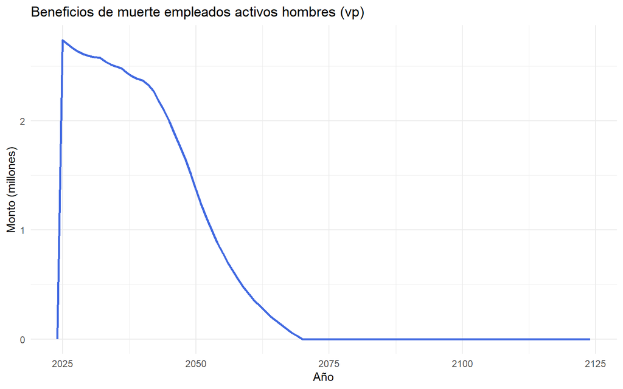

```r
ggplot() +
  geom_line(data = proy_H_fin,
            aes(x = Año, y = proy_emp_vp/1000000, color = "hombres"),
            size = 1) +
  scale_color_manual(
    values = c(
      "hombres" = "royalblue"
    )
  ) +
  labs(
    x = "Año",
    y = "Monto (millones)",
    title = "Beneficios de muerte empleados activos hombres (vp)",
    color = "Sexo"
  ) +
  theme_minimal() +
  theme(legend.position = "none")
```

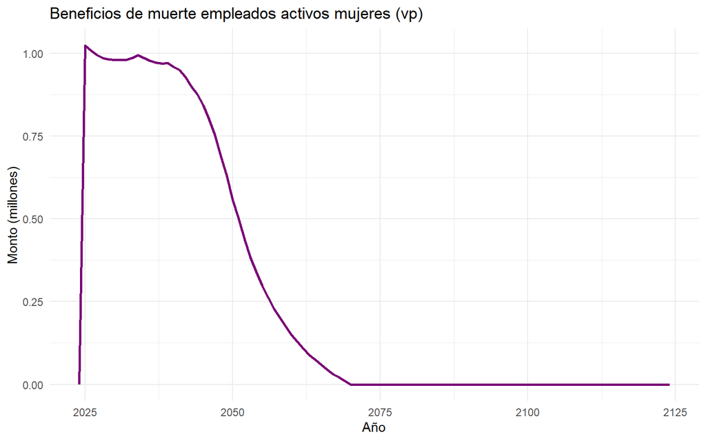

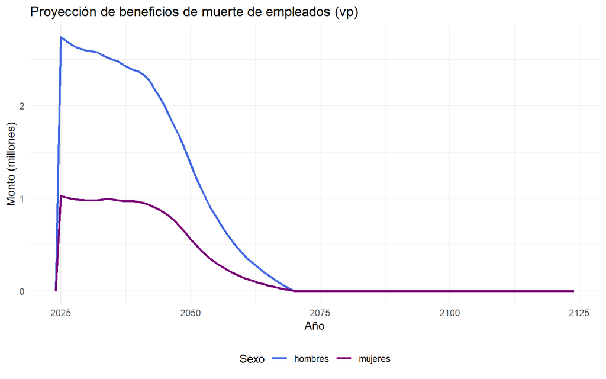

```r
ggplot() +
  geom_line(data = proy_M_fin,
            aes(x = Año, y = proy_emp_vp/1000000, color = "mujeres"),
            size = 1) +
  scale_color_manual(
    values = c(
      "mujeres" = "#7a0177"
    )
  ) +
  labs(
    x = "Año",
    y = "Monto (millones)",
    title = "Beneficios de muerte empleados activos mujeres (vp)",
    color = "Sexo"
  ) +
  theme_minimal() +
  theme(legend.position = "none")
```

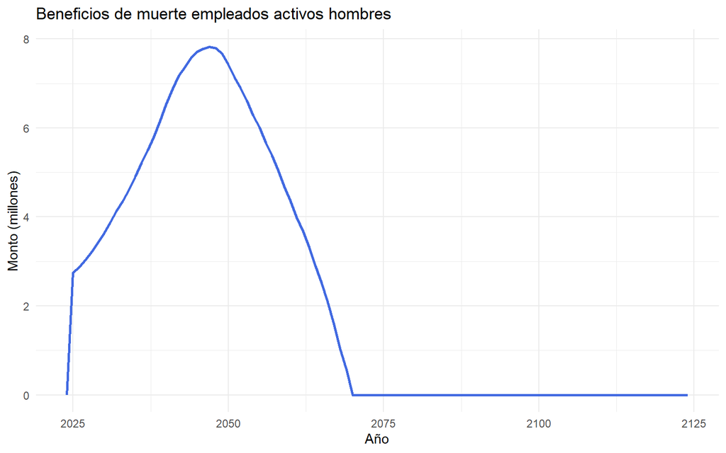

```r
ggplot() +
  geom_line(data = proy_H_fin,
            aes(x = Año, y = proy_emp_fin/1000000, color = "hombres"),
            size = 1) +
  scale_color_manual(
    values = c(
      "hombres" = "royalblue"
    )
  ) +
  labs(
    x = "Año",
    y = "Monto (millones)",
    title = "Beneficios de muerte empleados activos hombres"
  ) +
  theme_minimal() +
  theme(legend.position = 'none')
```

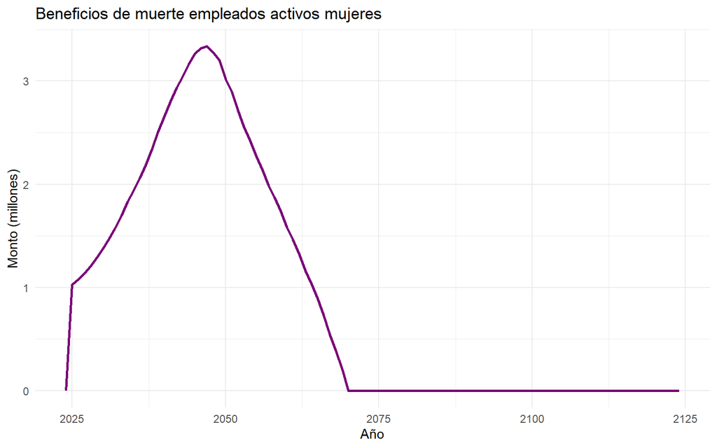

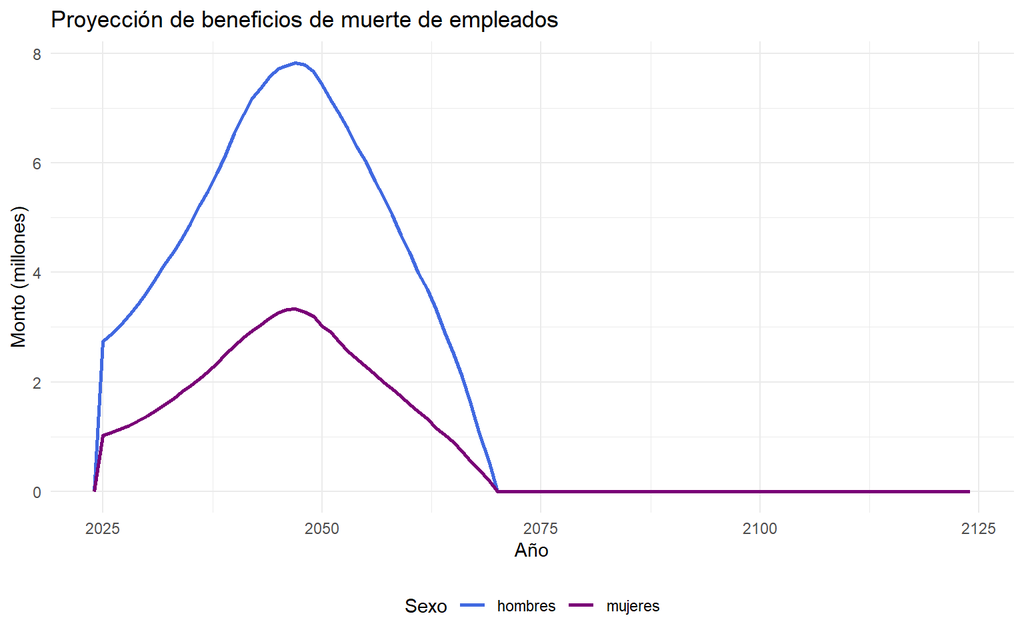

```r
ggplot() +
  geom_line(data = proy_M_fin,
            aes(x = Año, y = proy_emp_fin/1000000, color = "mujeres"),
            size = 1) +
  scale_color_manual(
    values = c(
      "mujeres" = "#7a0177"
    )
  ) +
  labs(
    x = "Año",
    y = "Monto (millones)",
    title = "Beneficios de muerte empleados activos mujeres",
    color = "Sexo"
  ) +
  theme_minimal() +
  theme(legend.position = "none")
```

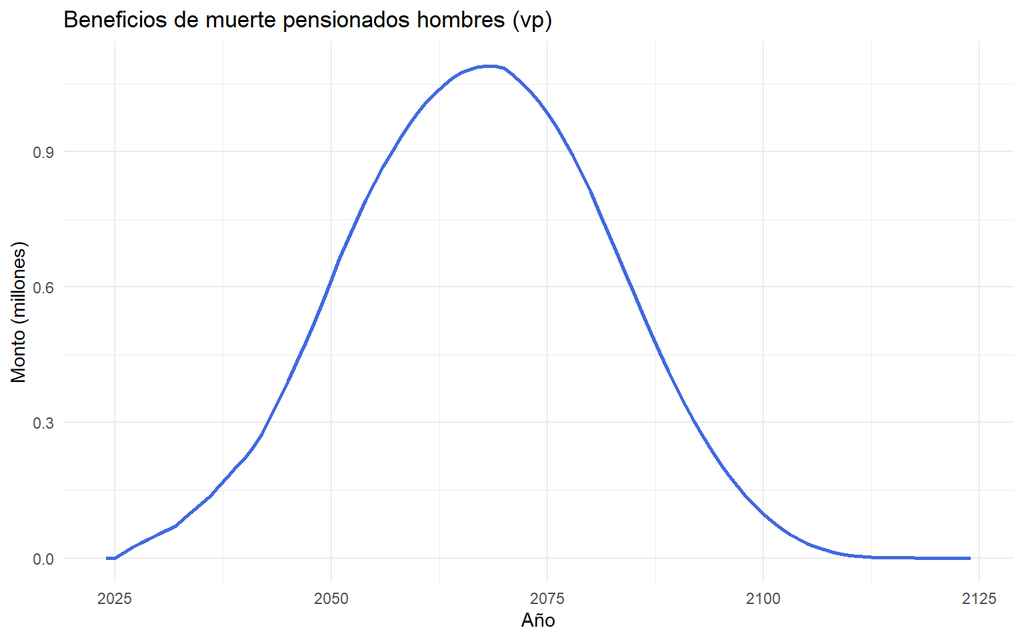

```r
ggplot() +
  geom_line(data = proy_H_fin,
            aes(x = Año, y = proy_pen_vp/1000000, color = "hombres"),
            size = 1) +
  scale_color_manual(
    values = c(
      "hombres" = "royalblue"
    )
  ) +
  labs(
    x = "Año",
    y = "Monto (millones)",
    title = "Beneficios de muerte pensionados hombres (vp)",
    color = "Sexo"
  ) +
  theme_minimal() +
  theme(legend.position = 'none')
```

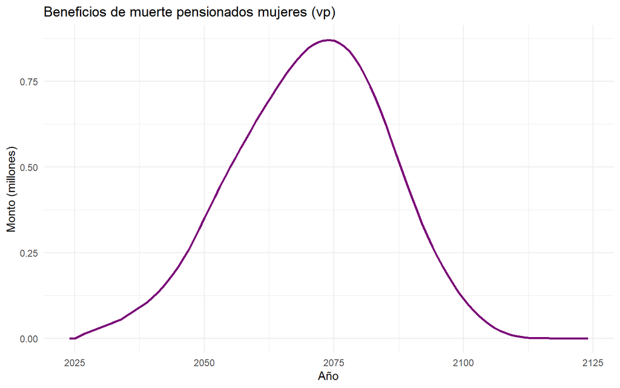

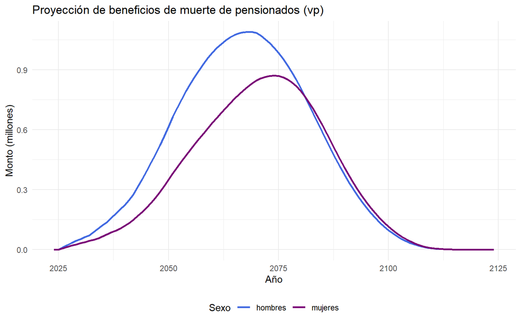

```r
ggplot() +
  geom_line(data = proy_M_fin,
            aes(x = Año, y = proy_pen_vp/1000000, color = "mujeres"),
            size = 1) +
  scale_color_manual(
    values = c(
      "mujeres" = "#7a0177"
    )
  ) +
  labs(
    x = "Año",
    y = "Monto (millones)",
    title = "Beneficios de muerte pensionados mujeres (vp)",
    color = "Sexo"
  ) +
  theme_minimal() +
  theme(legend.position = "none")
```

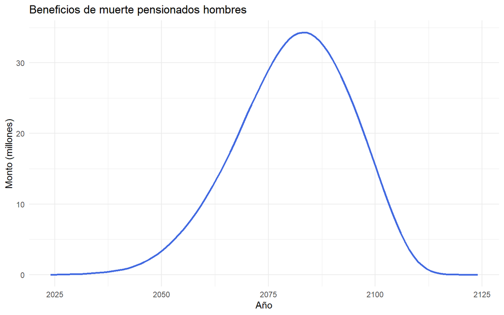

```r
ggplot() +
  geom_line(data = proy_H_fin,
            aes(x = Año, y = proy_pen_fin/1000000, color = "hombres"),
            size = 1) +
  scale_color_manual(
    values = c(
      "hombres" = "royalblue"
    )
  ) +
  labs(
    x = "Año",
    y = "Monto (millones)",
    title = "Beneficios de muerte pensionados hombres",
    color = "Sexo"
  ) +
  theme_minimal() +
  theme(legend.position = 'none')
```

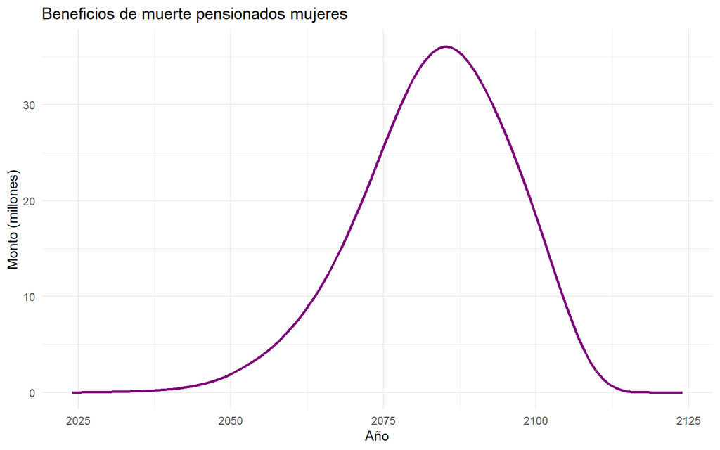

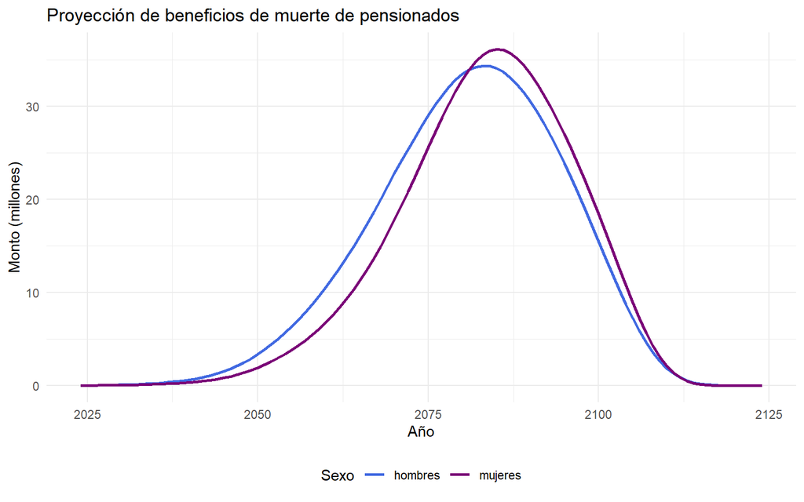

```r
ggplot() +
  geom_line(data = proy_M_fin,
            aes(x = Año, y = proy_pen_fin/1000000, color = "mujeres"),
            size = 1) +
  scale_color_manual(
    values = c(
      "mujeres" = "#7a0177"
    )
  ) +
  labs(
    x = "Año",
    y = "Monto (millones)",
    title = "Beneficios de muerte pensionados mujeres",
    color = "Sexo"
  ) +
  theme_minimal() +
  theme(legend.position = "none")
```